# Analysis of Experimental Data

R.J. Beck

5/18/2020

This script generates all figures that are derived directly from the experimental data i.e.:

Figures 1-2 Figures S1-S2

```r
base_dir <- "/home/richard/Documents/03_CTLsGoesNative/000_archive"
data_proc_funcs <- paste(base_dir,"/rscripts/utility/data_processing_functions.R",sep="")
source (data_proc_funcs)

require(ggplot2)
mouse_shapes <- c(0,1,2,5,12,13,4,9)
names(mouse_shapes) <- c(49,64,65,57,50,66,67,55)
mouse_colors <- c(1,2,3,4,1,2,3,4)
names(mouse_colors) <- c(49,64,65,57,50,66,67,55)
iv.proc <- get.iv()

dayz <- c("green", "blue")

dfstat <- aggregate(iv.proc[c("TCa","TCm")],by=iv.proc[c("ID","day","mouse")],mean)
dfstat1 <- aggregate(iv.proc[c("CTLa","CTLm")],by=iv.proc[c("ID","day","mouse")],mean)
dfstat$type <- "tumour"
dfstat1$type <- "CTL"
names(dfstat)[names(dfstat)%in%c("TCa","TCm")] <- c("apt","mit")
names(dfstat1)[names(dfstat1)%in%c("CTLa","CTLm")] <- c("apt","mit")
dfstat <- rbind(dfstat,dfstat1)
dfstat$net <- dfstat$mit-dfstat$apt

dfvec <- dfstat[dfstat$mouse!="m1",]
dfvec$uid <- interaction(dfvec$ID,dfvec$mouse,dfvec$type)


for(id in unique(dfvec$uid)){ ## get difference between day 6 and 9
  dfvec$apt[dfvec$uid==id] <- dfvec$apt[dfvec$uid==id]-dfvec$apt[dfvec$uid==id&dfvec$day==6]
  dfvec$mit[dfvec$uid==id] <- dfvec$mit[dfvec$uid==id]-dfvec$mit[dfvec$uid==id&dfvec$day==6]
}

ivstat <- iv.proc[,c("ID","mouse","day","TCa","TCm","TC","CTL")]
ivstat1 <- iv.proc[,c("ID","mouse","day","CTLa","CTLm","TC","CTL")]
ivstat$type <- "tumour"
ivstat1$type <- "CTL"
names(ivstat)[names(ivstat)%in%c("TCa","TCm")] <- c("apt","mit")
names(ivstat1)[names(ivstat1)%in%c("CTLa","CTLm")] <- c("apt","mit")
ivstat <- rbind(ivstat,ivstat1)
ivstat$net <- ivstat$mit-ivstat$apt
ivstat$cell_count <- ivstat$TC
ivstat$cell_count[ivstat$type=="CTL"]<-ivstat$CTL[ivstat$type=="CTL"]



x <- lapply(1:nrow(ivstat),function(i){
  x <- ivstat[i,]
  y <-subset(dfstat,mouse==x$mouse&type==x$type&day==x$day)
  return(data.frame(APT=y$apt,MIT=y$mit))
  })
x <- do.call(rbind,x)
ivstat<- cbind(ivstat,x)
ivstat$ID[ivstat$ID=="control"] <- "ACT-only"
ivstat$ID[ivstat$ID=="mAB"] <- "ACT+mAb"
dfstat$ID[dfstat$ID=="control"] <- "ACT-only"
dfstat$ID[dfstat$ID=="mAB"] <- "ACT+mAb"
dfvec$ID[dfvec$ID=="control"] <- "ACT-only"
dfvec$ID[dfvec$ID=="mAB"] <- "ACT+mAb"
```

```r
require(ggplot2)

p1 <- ggplot(subset(ivstat,type=="tumour"), aes(x=apt, y=mit))+
  facet_grid(cols=vars(ID))+
  geom_point(aes(shape=as.character(mouse),color=as.character(day)),size=2)+
  geom_abline(slope=1,intercept=0,color="red",linetype="dashed")+
  geom_point(data=subset(dfstat,type=="tumour"),aes(shape=as.character(mouse),color=as.character(day)),size=4)+
  geom_line(data=subset(dfstat,type=="tumour"),aes(group=as.character(mouse)))+
  scale_x_continuous(expression(paste("TC apoptosis ",(TC^-1~day^-1))))+
  scale_y_continuous(expression(paste("TC mitosis ",(TC^-1~day^-1))))+
  scale_color_manual("day",values=dayz)+
  scale_shape_manual("mouse",values=mouse_shapes)+
  theme_classic(base_size = 14)


p1a <- ggplot(subset(ivstat,type=="tumour"), aes(x=apt, y=mit))+
  facet_grid(cols=vars(ID))+
  geom_segment(aes(xend=APT,yend=MIT,color=as.character(mouse)))+
  geom_point(aes(color=as.character(mouse),size=cell_count))+
  scale_x_continuous(expression(paste("TC apoptosis ",(TC^-1~day^-1))))+
  scale_y_continuous(expression(paste("TC mitosis ",(TC^-1~day^-1))))+
  scale_color_viridis_d("mouse")+
  scale_size_area("TCs")+
  theme_classic(base_size = 14)



p2 <- ggplot(subset(ivstat,type=="CTL"), aes(x=apt, y=mit))+
 facet_grid(cols=vars(ID))+
  geom_point(aes(shape=as.character(mouse),color=as.character(day)),size=2)+
  geom_abline(slope=1,intercept=0,color="red",linetype="dashed")+
  geom_point(data=subset(dfstat,type=="CTL"),aes(shape=as.character(mouse),color=as.character(day)),size=4)+
  geom_line(data=subset(dfstat,type=="CTL"),aes(group=as.character(mouse)))+
  scale_x_continuous(expression(paste("CTL apoptosis ",(CTL^-1~day^-1))))+
  scale_y_continuous(expression(paste("CTL mitosis ",(CTL^-1~day^-1))))+
  scale_color_manual("day",values=dayz)+
  scale_shape_manual("mouse",values=mouse_shapes)+
  scale_linetype_discrete("")+
  theme_classic(base_size = 14)

p2a <- ggplot(subset(ivstat,type=="CTL"), aes(x=apt, y=mit))+
 facet_grid(cols=vars(ID))+
  geom_segment(aes(xend=APT,yend=MIT,color=as.character(mouse)))+
  geom_point(aes(color=as.character(mouse),size=cell_count))+
  scale_x_continuous(expression(paste("CTL apoptosis ",(CTL^-1~day^-1))))+
  scale_y_continuous(expression(paste("CTL mitosis ",(CTL^-1~day^-1))))+
  scale_color_viridis_d("mouse")+
  scale_size_area("CTLs")+
  theme_classic(base_size = 14)

p3 <- ggplot(subset(dfvec,type=="CTL"), aes(x=apt, y=mit))+
  facet_grid(cols=vars(ID))+
    geom_abline(slope=1,intercept=0,color="red",linetype="dashed")+
  geom_abline(slope=-1,intercept=0,color="red",linetype="dashed")+
  geom_point(aes(shape=as.character(mouse),color=as.character(day)),size=4)+
  geom_line(aes(group=as.character(mouse)))+
  scale_x_continuous(expression(paste("CTL apoptosis change",(d6-d9))))+
  scale_y_continuous(expression(paste("CTL mitosis change",(d6-d9))))+
  scale_color_manual("day",values=dayz)+
  scale_shape_manual("mouse",values=mouse_shapes)+
  scale_linetype_discrete("")+
  theme_classic(base_size = 14)

p4 <- ggplot(subset(dfvec,type=="tumour"), aes(x=apt, y=mit))+
  facet_grid(cols=vars(ID))+
  geom_abline(slope=1,intercept=0,color="red",linetype="dashed")+
  geom_point(aes(shape=as.character(mouse),color=as.character(day)),size=4)+
  geom_line(aes(group=as.character(mouse)))+
  scale_x_continuous(expression(paste("TC apoptosis change ",(d6-d9))))+
  scale_y_continuous(expression(paste("TC mitosis change ",(d6-d9))))+
  scale_color_manual("day",values=dayz)+
  scale_shape_manual("mouse",values=mouse_shapes)+
  scale_linetype_discrete("")+
  theme_classic(base_size = 14)

print("not rendering")
```

```
## [1] "not rendering"
```

```r
if(TRUE){
  p <- list(p1,p2,p3,p4)
  pad <- egg::ggarrange(p1,p2,p4,p3,nrow=2)
  pad_alliv <- egg::ggarrange(p1,p2,p1a,p2a,p4,p3,nrow=3)

}
```

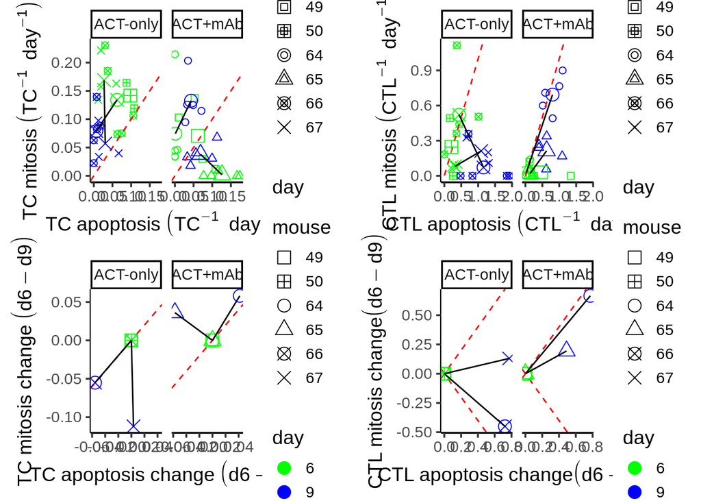

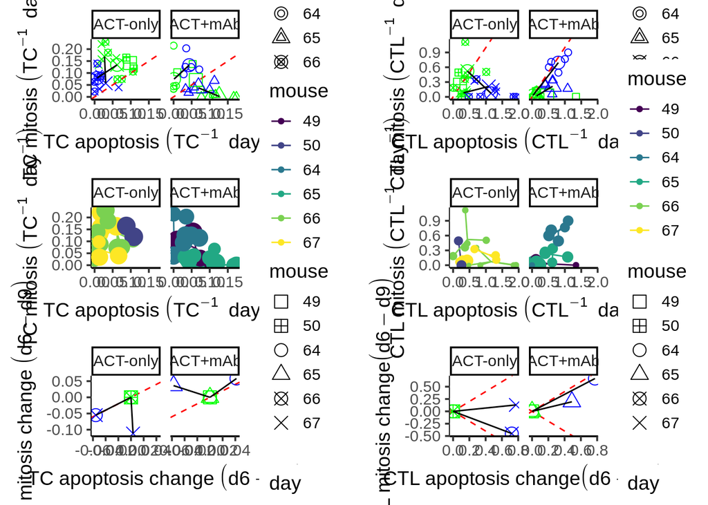

Tumour volume over time. First convert this to growth rate estimates, which comes with two benefits:

1. Second estimate for tumour growth. Can be compared to tumour mitosis rates to see if these are consistent. If not, suggests that the tumour is growing via “diffusive” means.
2. Avoids inaccuracies due to unknown volumetric density of tumour cells (results remain true so far as the density of the tumour remains constant, which the comparison with the mitosis data (1) reveals).

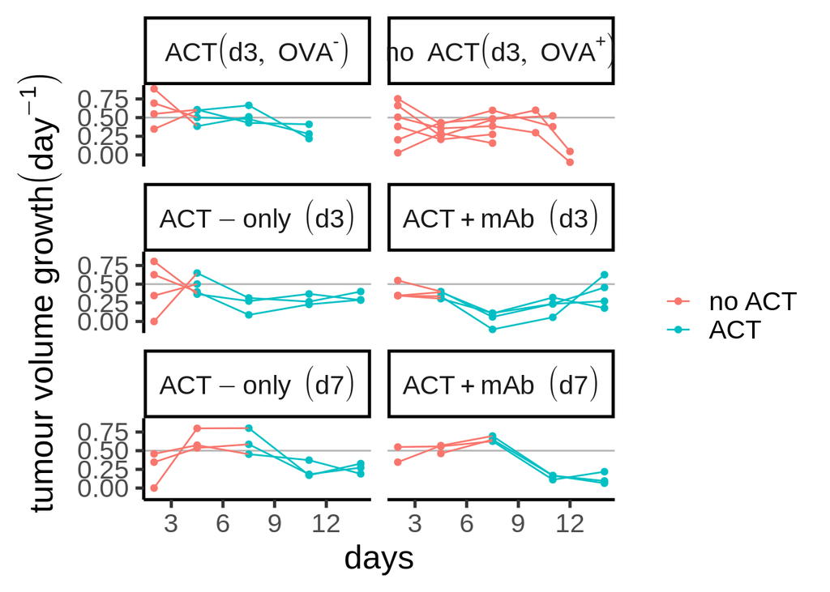

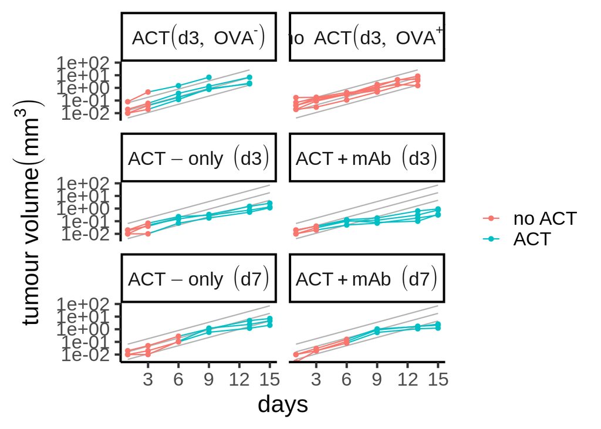

REVISED CODE FOR KILLING PARAMETER TESTING

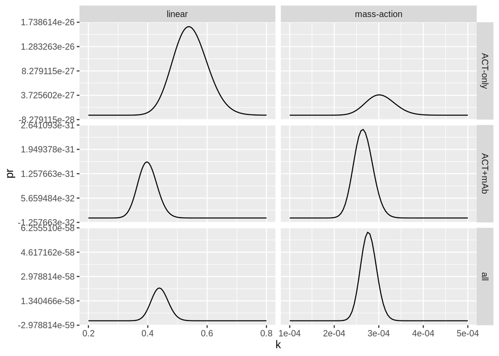

It is tricky to compare the likelihood scores between the the contacted-only and all-kills observations, because there are different numbers of available events. Case A) comparing contacted-only vs all-kills, there are simply more observed killing events in all-kills. Therefore, the probability of observing EXACTLY n kills is lower. Case B) if we try to include apoptosis in the contacted-only group, again it is not fair. Now we have to calculate the JOINT probability of EXACTLY n1 kills AND n2 apoptosis events.

Conclusion: we should be careful what we use these data to conclude! Conclusion! Based on these data, the best choice for a killing model could be EITHER:

linear killing - no difference between days or treatments dual-saturation - Either no difference between days or treatments, or grouped by day

Best thing to do with this data: leave out the dual-sat fit, compare only mass-action and constant.

THIS MIGHT BE WRONG (CODE IN FOLLOWING CHUNK), BECAUSE IF WE SPLIT THE DATA UP THEN WE NEED TO ADD AN EXTRA (HYPER)PARAMETER FOR EACH SPLIT, I RECKON. WE ARE GOING TO AVOID WORRYING ABOUT ANY OF THIS BY ONLY COMPARING THE MASS ACTION AND LINEAR FIT, AND ONLY LOOKING AT THE CASE WHERE WE FIT SEPARATE KILLING PARAMETERS PER GROUP. THAT IS BECAUSE WE WERE ONLY ASKED TO SHOW THAT THE NUMBER OF TUMOUR CELLS DOES NOT INFLUENCE THE KILLING RATE.

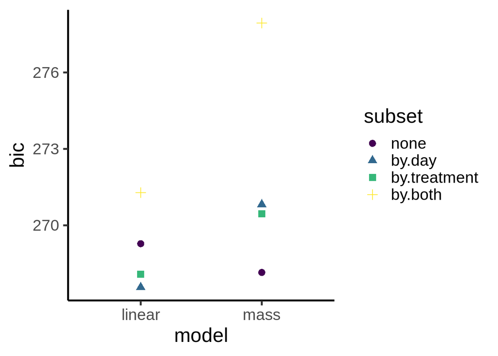

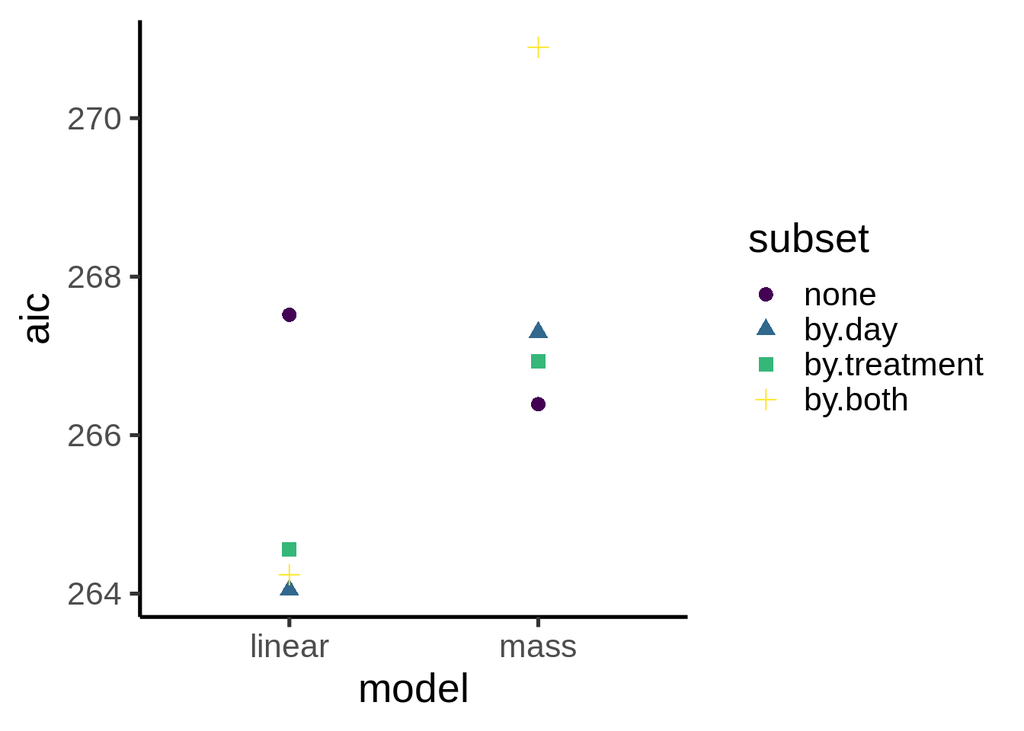

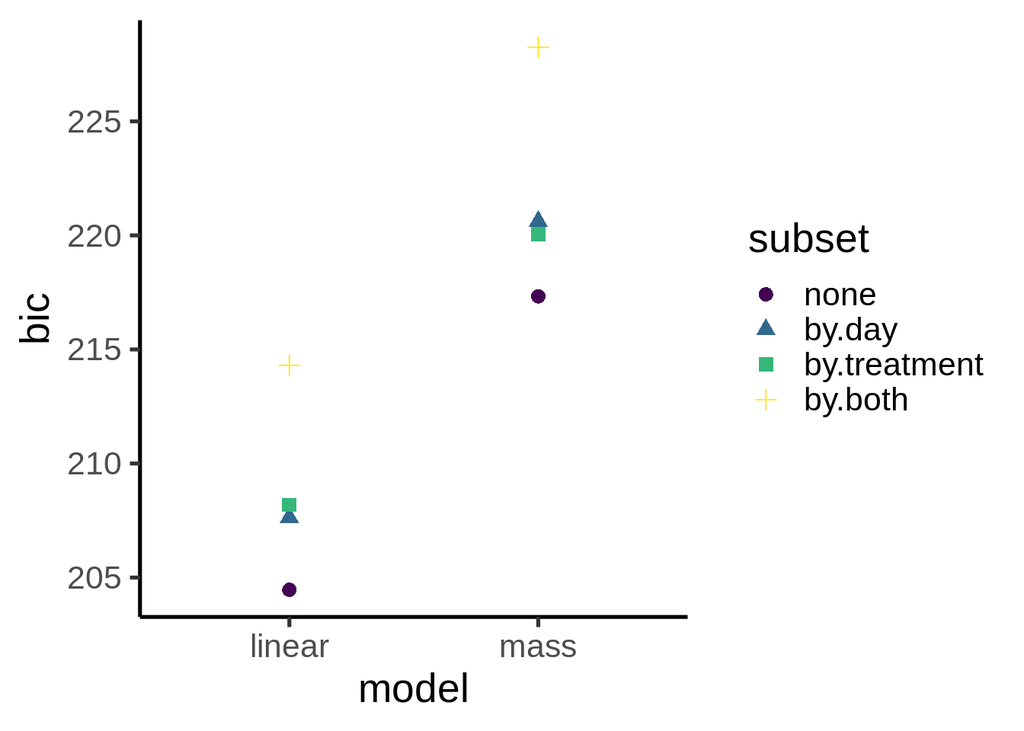

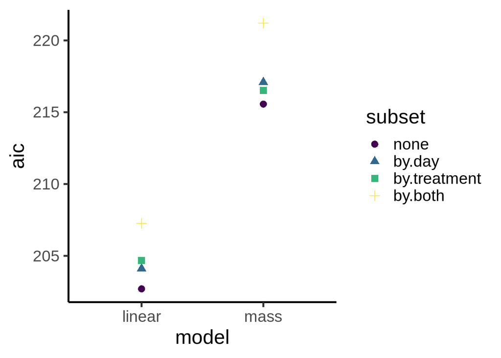

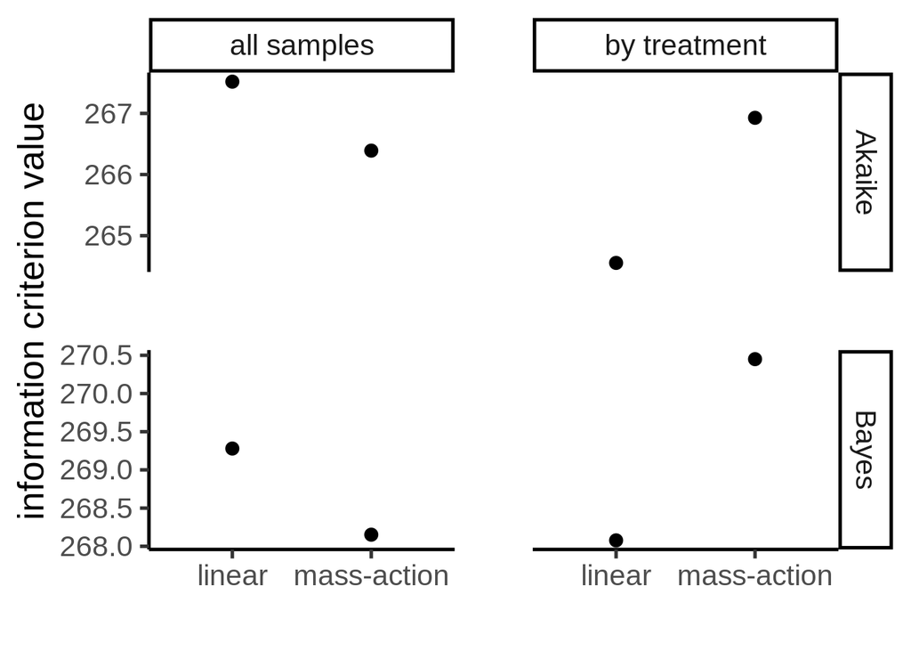

Retrieve best fitting killing rates for linear and mass-action killing

[output not shown]

retrieve the killing statistics from the data:

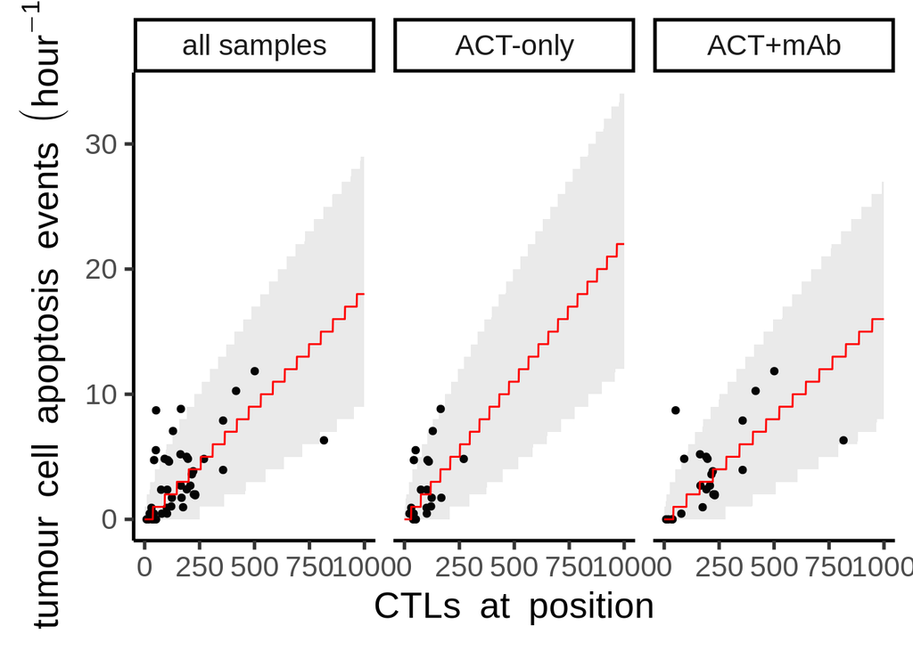

```r
labz <- as_labeller(c('all' = "all samples",
                           'mAB' = "ACT+mAb",
                           'control' = "ACT-only"))



p2c <- ggplot(subset(fits,type=="linear"),aes(x=X))+
  facet_grid(cols=vars(trt),scales = "free",labeller=labz)+
  geom_point(data=lin,aes(y=kills))+
  geom_ribbon(aes(ymin=conf05,ymax=conf95),alpha=0.1)+
  geom_line(aes(y=exp),color="red")+
  #geom_point(size=1.5,aes(color=treatment,y=TCa*TC/24))+
  theme_classic(base_size=20)+
  scale_x_continuous(expression(CTLs~at~position))+
  scale_y_continuous(expression(tumour~cell~apoptosis~events~(hour^-1)))
p2c
```